# How to use TOD class (todlib.py)

TOD クラスは時系列データを扱うクラスです。使用する際は、`ahiru:/home/hikaru/pythonlibs/todlib/todlib.py` にあるものをコピーして使うか、

```
$ git clone https://github.com/i-hikaru/todlib.git
```

として `todlib.py` をダウンロードしてください。folk は歓迎します。

## todlib.TOD

**class* todlib.TOD(filename, usecols=None)**

`filename` には処理したいファイル名を指定します。このとき読み込むデータは、1 列目がタイムスタンプになるように、`usecols` を指定します。

```
Parameters:
            filename: int
            読み込むファイルを指定します
            usecols: list
            読み込む列を指定します

Returns:
            out: pandas.core.frame.DaraFrame
```

TOD クラスは以下のメソッドを持ちます。

**ts(skip=1)**

TOD のタイムスタンプを返すメソッド。

```
Parameters:
            skip: int
            指定した整数だけデータを間引きます

Returns:
            out: numpy.ndarray
```

**dates(skip=1, tz=pytz.timezone('Asia/Tokyo'))**

TOD の時間情報を datetime モジュールの形式で返すメソッド。

```
Parameters:
            skip: int
            指定した整数だけデータを間引きます
            tz: pytz.tzfile
            pytz モジュールのタイムゾーンを指定します

Returns:
            out: numpy.ndarray
```

**vals(skip=1)**

TOD のすべての値を返すメソッド。

```
Parameters:
            skip: int
            指定した整数だけデータを間引きます

Returns:
            out: numpy.ndarray
```

**get_channel_vals(channel, skip=1)**

TOD の各チャンネルの値を返すメソッド。

```
Parameters:
            channel: int
            チャンネル番号を指定します
            skip: int
            指定した整数だけデータを間引きます

Returns:
            out: numpy.ndarray
```

TOD クラスのメソッドを使った以下の関数が定義されています。

**todlib.gentod(filename, usecols=None, skip=1, colslabel=None)**

指定したファイルの TOD を pandas モジュールの DataFrame 形式にする関数。

```
Parameters:
            filename: str
            読み込むファイルを指定します
            usecols: list
            読み込む列をしていします
            skip: int
            指定した整数だけデータを間引きます
            colslabel: list
            各チャンネルをラベリングします

Returns:
            out: Pandas.core.frame.DataFrame
```

**todlib.gentod_all(dirname, usecols=None, skip=1, colslabel=None, extension='dat')**

指定したディレクトリにあるすべての TOD を pandas モジュールの DataFrame 形式に結合する関数。

```
Parameters:
            dirname: str
            読み込むファイル群があるディレクトリを指定します
            usecols: list
            読み込む列をしていします
            skip: int
            指定した整数だけデータを間引きます
            colslabel: list
            各チャンネルをラベリングします
            extension: str
            データファイルの拡張子を指定できます

Returns:
            out: Pandas.core.frame.DataFrame
```

## Notes

TOD クラスは使用するデータのある path と使用する列を引数にとってオブジェクトをつくります。ここでは、LakeShore 218 で取得した 8 チャンネルの温度データを例に TOD クラスの使い方を説明します。

## Examples

LakeShore の温度データ（`/home/gb/public_html/gbmonitor/temp/data/lastest`）は 10 列の値（時刻, タイムスタンプ, チャンネル 1 の温度, ..., チャンネル 8 の温度）からなります。TOD クラスは 1 列目にタイムスタンプ、2 列目以降をそのときの値（この場合は温度）となるようにデータを指定します。いまの場合は 1 列目以降の列を `usecols` に指定します。また、各チャンネルを ch. 0, ch. 1, ..., ch. 7 とラベル付けしておきます。

```python
%matplotlib inline
import matplotlib.pyplot as plt
import matplotlib.dates as md
import pytz
import pandas as pd
import todlib

tod = todlib.gentod('/home/gb/public_html/gbmonitor/temp/data/lastest', usecols=range(1, 10), colslabel=['ch. '+str(i) for i in range(8)])
print tod
```

```
                            ch. 0   ch. 1   ch. 2   ch. 3   ch. 4   ch. 5  \
2014-10-25 02:50:09+09:00  279.82  283.97  282.53  279.44  279.45  280.19
2014-10-25 02:50:10+09:00  279.82  283.97  282.53  279.45  279.45  280.19
2014-10-25 02:50:11+09:00  279.82  283.97  282.53  279.44  279.45  280.18
2014-10-25 02:50:12+09:00  279.82  283.97  282.53  279.44  279.44  280.18
2014-10-25 02:50:13+09:00  279.82  283.97  282.53  279.44  279.44  280.18
2014-10-25 02:50:14+09:00  279.82  283.97  282.53  279.44  279.44  280.18
2014-10-25 02:50:15+09:00  279.82  283.97  282.53  279.44  279.44  280.18
2014-10-25 02:50:16+09:00  279.82  283.97  282.53  279.44  279.44  280.18
2014-10-25 02:50:17+09:00  279.82  283.96  282.53  279.44  279.44  280.18
2014-10-25 02:50:18+09:00  279.82  283.97  282.53  279.44  279.44  280.18
2014-10-25 02:50:19+09:00  279.82  283.96  282.53  279.44  279.44  280.18
2014-10-25 02:50:20+09:00  279.81  283.96  282.53  279.44  279.44  280.18
2014-10-25 02:50:21+09:00  279.81  283.96  282.53  279.44  279.44  280.18
2014-10-25 02:50:22+09:00  279.81  283.96  282.52  279.44  279.44  280.18
2014-10-25 02:50:23+09:00  279.81  283.96  282.52  279.44  279.44  280.17
2014-10-25 02:50:24+09:00  279.81  283.96  282.52  279.44  279.43  280.17
2014-10-25 02:50:25+09:00  279.81  283.96  282.52  279.44  279.43  280.17
2014-10-25 02:50:26+09:00  279.81  283.96  282.52  279.44  279.43  280.17
2014-10-25 02:50:27+09:00  279.81  283.96  282.52  279.43  279.43  280.17
2014-10-25 02:50:28+09:00  279.81  283.96  282.52  279.43  279.43  280.17
2014-10-25 02:50:29+09:00  279.81  283.96  282.52  279.43  279.43  280.17
2014-10-25 02:50:30+09:00  279.81  283.96  282.52  279.43  279.43  280.17
2014-10-25 02:50:31+09:00  279.81  283.96  282.52  279.43  279.43  280.17
2014-10-25 02:50:32+09:00  279.81  283.96  282.52  279.43  279.43  280.17
2014-10-25 02:50:33+09:00  279.81  283.96  282.52  279.43  279.43  280.17
2014-10-25 02:50:34+09:00  279.81  283.96  282.52  279.43  279.42  280.17
2014-10-25 02:50:35+09:00  279.81  283.96  282.52  279.43  279.42  280.16
2014-10-25 02:50:36+09:00  279.81  283.96  282.52  279.43  279.42  280.16
2014-10-25 02:50:37+09:00  279.81  283.96  282.52  279.43  279.42  280.16
2014-10-25 02:50:38+09:00  279.80  283.96  282.51  279.43  279.42  280.16
...                           ...     ...     ...     ...     ...     ...
2014-10-25 11:35:30+09:00  279.34  283.44  281.79  278.76  278.49  279.42
2014-10-25 11:35:31+09:00  279.34  283.44  281.79  278.76  278.48  279.42
2014-10-25 11:35:32+09:00  279.34  283.44  281.79  278.76  278.48  279.42
2014-10-25 11:35:33+09:00  279.34  283.44  281.79  278.76  278.49  279.42
2014-10-25 11:35:34+09:00  279.34  283.44  281.79  278.76  278.49  279.42
2014-10-25 11:35:35+09:00  279.34  283.44  281.79  278.76  278.49  279.42
2014-10-25 11:35:36+09:00  279.34  283.44  281.79  278.76  278.48  279.42
2014-10-25 11:35:37+09:00  279.34  283.44  281.79  278.76  278.48  279.42
```

[output cut: 72 more lines]

```
2014-10-25 11:35:47+09:00  279.33  279.24
2014-10-25 11:35:48+09:00  279.33  279.24
2014-10-25 11:35:49+09:00  279.33  279.23
2014-10-25 11:35:50+09:00  279.33  279.24
2014-10-25 11:35:51+09:00  279.33  279.23
2014-10-25 11:35:52+09:00  279.33  279.23
2014-10-25 11:35:53+09:00  279.33  279.24
2014-10-25 11:35:54+09:00  279.33  279.24
2014-10-25 11:35:55+09:00  279.33  279.23
2014-10-25 11:35:56+09:00  279.33  279.23
2014-10-25 11:35:57+09:00  279.33  279.23
2014-10-25 11:35:58+09:00  279.33  279.23
2014-10-25 11:35:59+09:00  279.33  279.24

[31505 rows x 8 columns]
```

pandas の `plot()` メソッドを使ってデータをプロットできます。

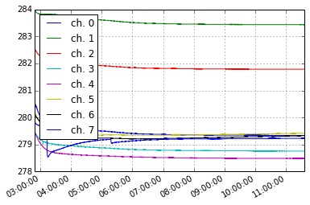

```python
tod.plot()
plt.show()
```

`todlib.gentod()` は pandas の DataFrame を返すので、`plot()` に限らず、様々なメソッドを使うことができます（ref., [pandas.DataFrame — pandas 0.14.1 documentation](http://pandas.pydata.org/pandas-docs/dev/generated/pandas.DataFrame.html)）。

ある特定の期間をプロットするには以下のようにします。

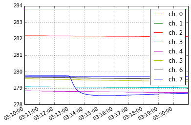

```python
tod['2014-10-25-0310':'2014-10-25-0320'].plot()
show()
```

これまでに取得した各 TOD をまとめて処理したい場合は、`todlib.gentod_all()` を使います。

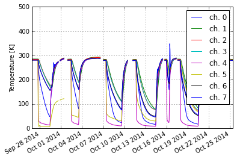

```python
todAll = todlib.gentod_all('/home/gb/public_html/gbmonitor/temp/data', usecols=range(1, 10), colslabel=['ch. '+str(i) for i in range(8)])
ax = todAll['2014-09-26':'2014-10-25'].resample('H').plot()
ax.set_ylabel('Temperature [K]')
plt.show()
```